# section2

2022-11-20

## データの視覚的表現

### table

```r
指導法 <- c("C", "B", "B", "A", "B", "C", "A", "D", "D", "D", "A", "A", "A", "C", "B", "D", "C", "C", "B", "D")
table(指導法)
```

```
## 指導法
## A B C D
## 5 5 5 5
```

### ヒストグラフ

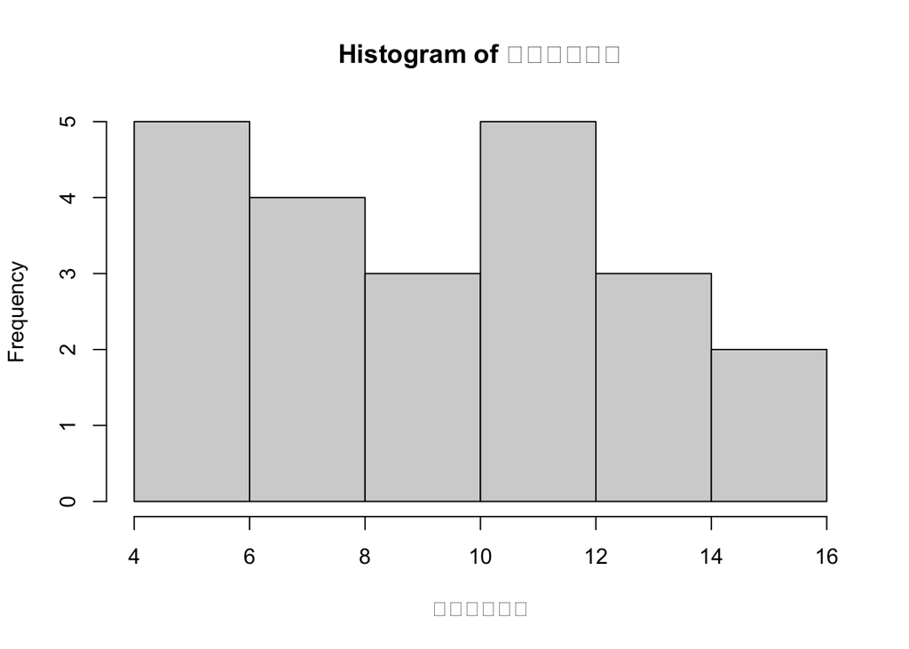

```r
心理学テスト <- c(13, 14, 7, 12, 10, 6, 8, 15, 4, 14, 9, 6, 10, 12, 5, 12, 5, 12, 8, 8, 12, 15)
hist(心理学テスト)
```

### 代表値

```r
テストa <- c(10, 13, 8, 15, 8)
# sum(テストa)/5 でも行けるがmean使えば一発
mean(テストa)
```

```
## [1] 10.8
```

- 代表値としては平均が使われることが最も多い

```r
median(テストa)
```

```
## [1] 10
```

- 外れ値がある場合などは平均ではなく中央値が使われることも

```r
table(テストa)
```

```
## テストa
##  8 10 13 15
##  2  1  1  1
```

- 最頻値の関数はないのでtable関数を使うと良い
- 質的変数の代表値として使われる
  - 性別、職業、配偶者の有無など単に分類や種類を区別するための変数

## 分散、標準偏差

```r
標本分散 <- sum((テストa - mean(テストa))^2) / length(テストa)
sqrt(標本分散)
```

```
## [1] 2.785678
```

上記でも分散でるけど `var` で一発。

```r
不偏分散 <- var(テストa)
sqrt(不偏分散)
```

```
## [1] 3.114482
```

- ただし、varで出るのは不偏分散なので、データの個数 - 1で割った結果になる
  - 標本分散の方は標本の数のみで分散を出す
  - 不偏分散は標本の母集団全体についての分散を推定するために使われる
    - 標本分散は母集団の分散より小さくなる性質があるので n - 1 して補正してる

## 標準化

```r
心理学平均 <- mean(心理学テスト)
心理学平均
```

```
## [1] 9.863636
```

```r
心理学標準偏差 <- sqrt(mean((心理学テスト-心理学平均)^2))
心理学標準偏差
```

```
## [1] 3.374981
```

```r
心理学z得点 <- (心理学テスト-心理学平均)/心理学標準偏差
心理学z得点
```

```
##  [1]  0.92929820  1.22559617 -0.84848966  0.63300022  0.04040427 -1.14478763
##  [7] -0.55219168  1.52189415 -1.73738359  1.22559617 -0.25589371 -1.14478763
## [13]  0.04040427  0.63300022 -1.44108561  0.63300022 -1.44108561  0.63300022
## [19] -0.55219168 -0.55219168  0.63300022  1.52189415
```

- 標準偏差を変換して、平均を中央に寄せたのが標準得点というざっくり理解
  - 中でも、正規分布に合うように平均0, SD1になるように標準化された得点はz-scoreと呼ばれる
- 標準的な分布である正規分布に合わせる作業なので標準化

```r
心理学z得点平均 <- mean(心理学z得点)
心理学z得点平均
```

```
## [1] 8.959452e-17
```

```r
心理学z得点標準偏差 <- sqrt(mean((心理学z得点-心理学z得点平均)^2))
心理学z得点標準偏差
```

```
## [1] 1
```

- z-scoreから標準偏差計算し直すと、平均は0に限りなく近い値、SDは1になっていることがわかる

## 偏差値

```r
心理学標準偏差 <- 10*心理学z得点+50
心理学標準偏差
```

```
##  [1] 59.29298 62.25596 41.51510 56.33000 50.40404 38.55212 44.47808 65.21894
##  [9] 32.62616 62.25596 47.44106 38.55212 50.40404 56.33000 35.58914 56.33000
## [17] 35.58914 56.33000 44.47808 44.47808 56.33000 65.21894
```

```r
max(心理学標準偏差)
```

```
## [1] 65.21894
```

```r
min(心理学標準偏差)
```

```
## [1] 32.62616
```

- 偏差値とは平均50, SD10になるように標準化した標準得点